# Lecture 16: Loading Shapefiles into R

October 28, 2016

## Recall: sp Package

The `sp` package has tools for loading/storing **vector** data in R. `sp` stands for `SpatialPolygons`

[figure not shown]

## Road Map

- **Last time**: We are given a `SpatialPolygonsDataFrame` object, which we convert to tidy data format using `broom::tidy()` so we can `ggplot()` it
- **Today**: We are given **shapefiles**, which we import into R to a `SpatialPolygonsDataFrame` object, which we convert …

## Today's Goal

A [Choropleth Map](https://en.wikipedia.org/wiki/Choropleth_map) of Vermont census tract populations based on 2010 Decennial Census counts. We'll need

1. The `rgdal` package: To import shapefiles into R as a `SpatialPolygonsDataFrame` object. See `Lec16.R`
2. Social Explorer: To download census data. See instructions on lecture page.

## Shapefiles

A Geographic Information Systems (GIS) shapefile is a popular geospatial vector data format. It is developed and regulated by Esri as a (mostly) open specification for data interoperability among Esri and other GIS software products.

An all alternative format is GeoJSON files, which you can import into R using ROpenSci's geojson package.

## Shapefiles

A shapefile has three mandatory files:

1. `.shp` — shape format; the feature geometry itself
2. `.shx` — shape index format; a positional index
3. `.dbf` — data about the geographic objects

Sometimes also

1. `.prj` — information on the coordinate system/projection format used. Examples:
   - [Universal Transverse Mercator (UTM)](https://en.wikipedia.org/wiki/Universal_Transverse_Mercator_coordinate_system)
   - [World Geodetic System (WGS)](https://en.wikipedia.org/wiki/World_Geodetic_System)

## Next, the Census

Article I, Section 2 of the US Constitution states: *The actual Enumeration shall be made within three Years after the first Meeting of the Congress of the US, and within every subsequent Term of ten Years…*

i.e. there is **no sampling**, it is an exhaustive count.

[figure not shown]

## Census

The purpose of census is congressional apportionment: the 435 seats in the US House of Representatives get distributed proportionally to their population. After the 2010:

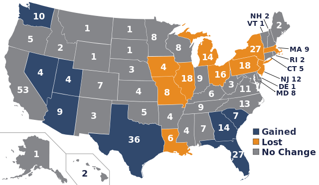

## Census vs American Community Survey

- The census only tracks limited info: population split by age, gender, race, household info.
- The American Community Survey (ACS) however tracks more information, but we only have **estimates** of quantities, not exhaustive counts: including income and poverty.